Lightly adapted from https://coxpress.sourceforge.net/tutorial_code.html by Katherine Wang.

Please note that there are extensive examples both in the coXpress help:

```r
library(coXpress)
#?coXpress
```

and on the coXpress website: http://coxpress.sf.net/code.R

# Step 1: reading your data in

Examples are provided here of reading in both a text file (golub.txt) and an Excel spreadsheet (golub.xls). The data should have rows representing genes and columns representing arrays. There should be one column containing unique gene identifiers.

If your data is in a text file….

```r
# here we use the read.table command.  This command reads in text files.  See
# ?read.table for help.  Our gene identifiers are in row 1, and so we pass 1
# to the row.names argument
golub.df <- read.table("golub.txt", sep="\t", header=TRUE, row.names=1)
```

If your data is in an Excel Spreadsheet (note: I’ve commented this all out because odbcConnectExcel doesn’t work with 64-bit Windows)

```r
# here we use the RODBC library
##library(RODBC)

# we tell it where our spreadsheet is
##xl <- odbcConnectExcel("golub.xls")

# we tell it what the worksheet is called sheet1
# this time we tell it the name of the column containing our gene identifiers
##golub.df <- sqlFetch(xl, "golub", rownames="Gene")

# once we have
##odbcCloseAll()
```

# Step 2: Cluster data based on a subset of experiments.

The golub data has 27 ALL cases and 11 AML cases. We will cluster on the 27 ALL cases.  
(Note: ALL = acute lymphoblastic leukemia, AML = acute myeloid leukemia. So these are the two conditions between which the differential coexpression is examined. The goal of this study was to determine the distinction between these two kinds of leukemia. In other datasets, you might compare the control group against the treatment group.)

```r
# ALL cases are in columns 1-27
hc.gene  <- cluster.gene(golub.df[,1:27],s="pearson",m="average")
```

# Step 3: cut the tree at a height of 0.4 (equates to pearson correlation of 0.6).

This choice of cut off is user defined and should be in the range 0 < h < 2. A low value will produce many groups with few genes in each group; a large value will produce few groups with many genes.

```r
g <- cutree(hc.gene, h=0.4)
```

# Step 4: examine the difference between ALL and AML samples.

```r
# The AML samples are in columns 28-38
cox <- coXpress(golub.df, g, 1:27, 28:38)
```

# Step 5: view results.

The results are a data.frame, with one row for each group of genes. See ‘?coXpress’ for a longer explanation of the columns and their meanings.

```r
# Examine the top 30 results
cox[1:30,]
```

```
##     group N         t1          t2 pr.g1 pr.g2 mean.corr1   mean.corr2
## 301   301 3  34.999432 -2.28233862     0  0.98  0.7396121 -0.388104224
## 345   345 3  16.977776 -1.53200283     0  0.93  0.7208147 -0.305707028
## 225   225 3 155.298104 -1.51573003     0  0.93  0.6995386 -0.286811514
## 44     44 3  66.926609 -1.44197034     0  0.91  0.6958237 -0.277549980
## 67     67 3  11.583685 -1.82635454     0  0.96  0.6625571 -0.305482077
## 809   809 3  51.944759 -0.86160165     0  0.82  0.7126734 -0.251203120
## 247   247 3  15.625166 -1.66238931     0  0.94  0.6794195 -0.281687602
## 578   578 3   7.960470 -6.85712394     0  0.99  0.6744456 -0.250063271
## 33     33 3  16.277848 -1.66660386     0  0.94  0.7497012 -0.153160527
## 552   552 3  20.206495 -1.61132751     0  0.93  0.6499683 -0.221783396
## 243   243 3 374.675194 -0.56038235     0  0.69  0.7409882 -0.129389083
## 152   152 4  18.512745 -1.21130404     0  0.85  0.6621547 -0.182273881
## 198   198 3  15.475256 -2.46687430     0  0.99  0.6399279 -0.197178562
## 426   426 3  11.950431 -0.60152737     0  0.71  0.6769853 -0.147291459
```

[output cut: 47 more lines]

# Step 6: examine groups of interest graphically

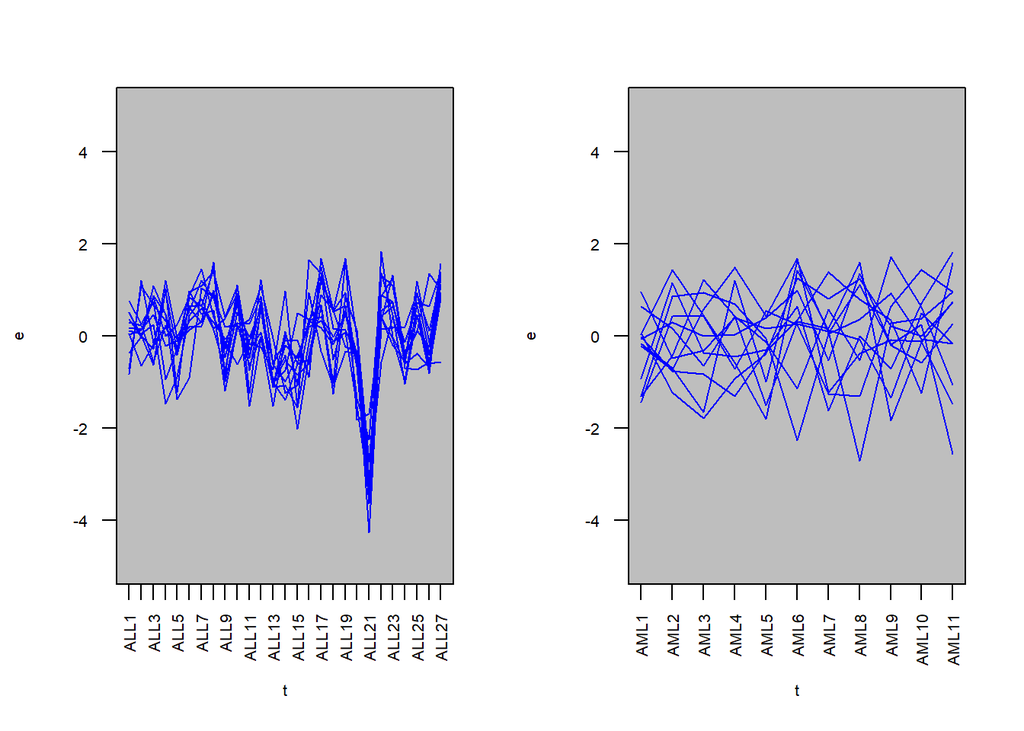

```r
# look at group 21
plot.compare.group(golub.df,g,21,1:27,28:38,
                    scale.center=TRUE,scale.scale=TRUE,
                    ylim=c(-5,5))
```

```r
inspect.group(golub.df,g,21,1:27,28:38)
```

```
##               GeneA            GeneB Cor Group 1  Cor Group 2
## 6       AB002559_at        U86409_at   0.7041030 -0.650277448
## 55        U86409_at      M74715_s_at   0.7869602 -0.513087934
## 26        M81057_at        X80907_at   0.6517622 -0.604077880
## 51        U73328_at U41068_cds2_s_at   0.6596748 -0.567375014
## 8       AB002559_at   U36341_rna1_at   0.7600084 -0.426579055
## 30        M81057_at U41068_cds2_s_at   0.7477505 -0.417324489
## 52        U86409_at        X80907_at   0.8104584 -0.342425664
## 36   U50136_rna1_at M19508_xpt3_s_at   0.6405531 -0.450032850
## 64 M19508_xpt3_s_at      M74715_s_at   0.6909407 -0.399220210
## 1       AB002559_at        M55150_at   0.7426254 -0.344354804
## 34   U50136_rna1_at        X80907_at   0.7434004 -0.319093786
## 11      AB002559_at U41068_cds2_s_at   0.7328891 -0.301533535
## 31   U50136_rna1_at        U71088_at   0.4608021 -0.572144940
## 9       AB002559_at M19508_xpt3_s_at   0.5840268 -0.424266198
```

[output cut: 52 more lines]

```r
# look for groups of genes with >= 10 members
cox[cox$N>=10,]
```

```
##     group  N        t1          t2 pr.g1 pr.g2 mean.corr1   mean.corr2
## 3       3 34 155.69767   0.1759069     0  0.44  0.7012601  0.002587009
## 21     21 12  51.18428  -0.8376484     0  0.78  0.6590528 -0.035278930
## 401   401 11  62.86866   2.2110604     0  0.05  0.7431540  0.120751622
## 96     96 13  54.29634   2.2466630     0  0.03  0.6918650  0.079627695
## 78     78 10  50.37600   1.0408969     0  0.10  0.6559525  0.049546337
## 121   121 11  54.77229   1.8357534     0  0.08  0.6793988  0.085609082
## 4       4 16  61.52938   4.0770617     0  0.00  0.6947325  0.146782815
## 270   270 10  44.08829   3.0901091     0  0.01  0.6858813  0.153053248
## 54     54 17  93.16716   5.2551876     0  0.00  0.6664849  0.149353444
## 6       6 28 118.37054   8.2814687     0  0.00  0.6626025  0.175065929
## 234   234 10  65.55791   5.1454868     0  0.00  0.7162007  0.243897501
## 125   125 11  54.41350   4.9253623     0  0.00  0.6578373  0.186467988
## 117   117 20  83.24019   6.3748318     0  0.00  0.6429913  0.177863996
## 114   114 14  75.00537   6.2242465     0  0.00  0.6739633  0.211546874
```

[output cut: 31 more lines]

```r
# look for groups of genes with >= 8 members
# that are non-random in group 1 and random
# in group 2
cox[cox$N>8 & cox$pr.g1<=.05 & cox$pr.g2>=.05, ]
```

```
##     group  N        t1         t2 pr.g1 pr.g2 mean.corr1   mean.corr2 mean.diff
## 3       3 34 155.69767  0.1759069     0  0.44  0.7012601  0.002587009 0.6986730
## 21     21 12  51.18428 -0.8376484     0  0.78  0.6590528 -0.035278930 0.6943318
## 401   401 11  62.86866  2.2110604     0  0.05  0.7431540  0.120751622 0.6224024
## 78     78 10  50.37600  1.0408969     0  0.10  0.6559525  0.049546337 0.6064062
## 121   121 11  54.77229  1.8357534     0  0.08  0.6793988  0.085609082 0.5937897
```